# Causality Factors for Good Academic Achievements

Yanwen Zhao, Yifan Yang, Jinglan Sun, Weichung Sun

## 1.Introduction

Math plays an important role in human thought and logic, as it helps build mental discipline, encourage logic reasoning and metal rigor. In the school, math acts as a fundamental subject in overall curriculum, improves student’s understanding in science, engineering, even in arts and music. Because of its transversal nature, it served as mental discipline for other disciplines. The principles and inner mechanisms under these subjects (science, engineering, economics etc.) often required sophisticated mathematical models (Matos, 2009; The Role of Mathematics in the Overall Curriculum | International Mathematical Union (IMU), 2008).  
From 1960s, the Modern Mathematics movement spread through many countries and influenced the content and methods of mathematics teaching. José Calado outlined that the spirits of the movement was the increment of class time spent on mathematics, algebra, and logic. The movement happened under the post-war era that aimed to strengthen industries and further economic integration with other countries. From then, mathematics serves as mandatory courses through the education programs. In 1990-2000, the students’ enrolments rate increased by 105.8% (Matos, 2009; The Ministry of Science, Technology and Higher Education, 2006).  
However, the failure and drop rate in Portugal were among the highest within Europe. In 2006, the early school leaving rate in Portugal was 40%, compared to the European Union average of 15% (Cortez & Silva, 2008; European Commission & Statistical Office of the European Union, 2007). In Portuguese population aged 25-64, the percentage of people who reached academic qualified upper secondary education was only 13% in 2001, similar to those of developing countries, such as Mexico and Turkey (The Ministry of Science, Technology and Higher Education, 2006). Thus, it’s becoming urgent to find effective ways for students in Portugal to improve mathematics achievement.  
Generally, attending extra paid classes is treated as a method to enhance academic performance. In extra paid classes, students receive guidance in reviewing school contents, doing homework, and preparing for examinations. Taking extra paid classes becomes quite common worldwide, especially in East Asia. Among Japanese secondary school students, 80% of them attended extra paid classes outside of school (Ömeroğulları et al., 2020).  
In Portugal, taking extra paid classes was not only a phenomenon among students with low academic achievement. The high-achieving students also took extra paid classes to maintain or further enhance their academic achievements. In the research conducted during 2005 and 2008, as shown in Table 1, mathematics was the most demanding subject among students in 12th grade (secondary education program). Similar results were also found in the ‘Xplika’ questionnaire distributed by the Portuguese Ministry of Education. Among students who took the extra paid classes outside school, 72.0% of them took mathematics classes. The reasons of taking extra paid classes can be concluded as the goal to “get a mark that will allow access to the degree of choice in higher education” (Neto-Mendes et al., 2013).

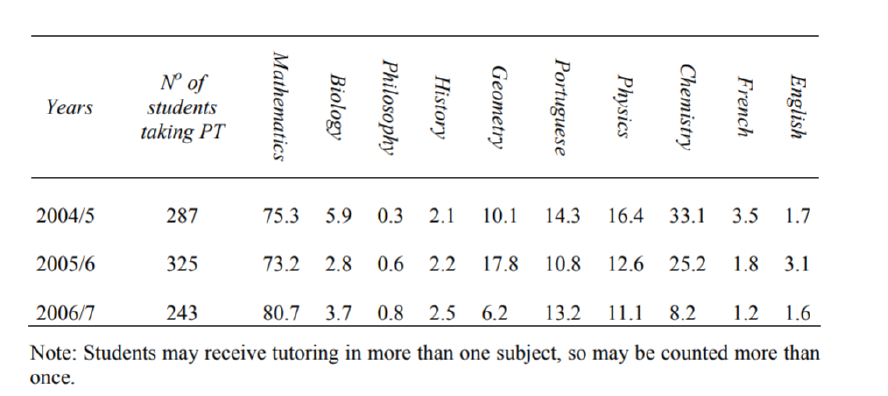

Although it’s common to believe taking extra paid classes benefits student’s grades. Conflicting results were found in the past empirical studies (Ömeroğulları et al., 2020). In Berberoğlu’s research among students in Turkish secondary high schools, positive association was found between taking extra paid classes and mathematical grades, but was relatively small compared to other variables (Berberoğlu & Tansel, 2014). The similar result appeared in Guill’s research, that there was no significant improvement on students’ mathematics achievement after matching on all other variables (Guill & Bos, 2014). But in the research conducted in Chinese and Korean regions, the significant influences can be found in the schools which are located in urban areas (Ha & Park, 2017; Zhang, 2013).  
As mathematics serves as fundamental subjects among all curriculum and students in Portuguese secondary schools has low mathematics achievements among European countries, it has become urgent to improve mathematics grades. Generally, taking extra paid classes are considered to be the method which favors grade improvement. However, multiple research projects indicated mixing conclusions regarding the relationship between taking extra paid classes and improvement of mathematics grades. In this study, we aim to identify the causality between taking extra paid classes and final mathematics grades among students in Portuguese secondary schools.

## 2.Methodology

In this section, we briefly illustrate the methods we use in this report. Section 2.1 is Propensity Score Model, section 2.2 is Average Causal Effects Estimation Method.

### 2.1.Propensity Score Model

In order to estimate causal effect as in a randomized study for observational studies, we are required to condition on baseline covariates, denoted as X. However, if X contains a large number of covariates, conditioning on X is almost impossible. In these scenario, the propensity score methods (Rosenbaum and Rubin, 1983) can be extreme helpful, because propensity score is a scalar, it’s free of dimension of X.  
Propensity score is the conditional probability of being treated given baseline covariates.

We should note that, in observational studies, $ps(x)$ is **unknown and must be estimated**. There are several approaches for estimating propensity score, such as logistic regression and also machine learning based methods. In this report, we use **Generalized Boosted Model** and **logistic regression** to build the propensity score model.  
Before building the propensity score model, we may do variable selection, but it’s important to note that we would like to make sure we include confounders in our model. That is, we include variables that are predictive of the outcome because real confounders are normally predictive of the outcome.

### 2.2 Average Causal Effects Estimation

In this section, we introduce some propensity score based methods to estimate causal effects, that is, using the estimated propensity score to adjust the original sample and estimate causal effects. There are also several propensity score based methods for estimating causal effects, such as Matching, Stratification, Inverse Probability Weighting, Double Robust Method and Multiple Robust Method. In this report, we implement Matching (Rosenbaum and Rubin, 1983) and Inverse Probability Weighting (Lunceford JK and Davidian M, 2004) for estimating the causal effect.

#### 2.2.1.Matching

Propensity score matching entails creating matched sets of treated and untreated subjects who share a similar value of the propensity score. The common implementation of propensity score matching is one-to-one to one-to-three matching, in which groups of treated and untreated subjects are created, such that matched subjects have similar values of the propensity score.  
Once a matched sample has been created, the treatment effect can be estimated by directly comparing outcomes between treated and untreated subjects in the matched sample.

Due to our data property that the treated and untreated sample number are nearly 1:1, we use one-to-one matching in the application section. However, the data also exist overlapping issue, so we do matching with replacement.

#### 2.2.2.Inverse Probability Weighting

It’s simple to tell by its name, the weights of IPW are assigned to patients based on the inverse of estimated propensity score (estimated probability of being treated given X).

- For treated group($T_i=1$), assign a weight $w_i=\frac{1}{\hat{ps}(X_i)}$
- For control group($T_i=1$), assign a weight $w_i=\frac{1}{1-\hat{ps}(X_i)}$

## 3. Estimating the effect of extra-paid classes

### 3.1 Overview of the data

The database consists of the questionnaires and school reports that collected information in the 2005-2006 year from two Portuguese secondary schools. In the questionnaire, multiple factors were included: age, sex, demographic information, social related information, etc (As shown in Table below). And grades are provided through school reports. In the Portuguese secondary education system, a 20-point grading system is used. In the 20-point grading system, 20 represents a perfect grade while 0 represents the lowest grade. Thus, the database consisted of 29 covariates and one potential outcome (final grade) (Cortez and Silva, 2008). The study object is to investigate the causality between taking extra classes and final mathematics grades. In this research, we treated the final grades as a standard outcome for students’ mathematics achievement. The covariate **paid** (taking extra grade) shows information about whether the students take extra classes outside school, where 1 indicates taking extra paid classes and 0 indicates without taking any extra paid classes. From Fig 1, 54.2%(214) of students in the database don’t take the extra paid classes while 45.8%(181) of students do (Cortez and Silva, 2008).

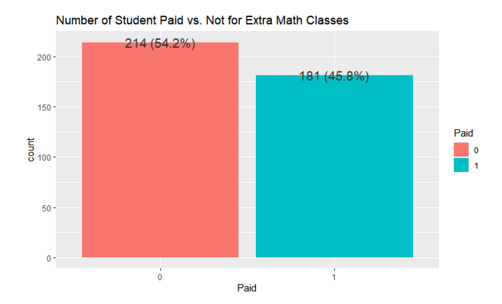

### 3.2 Estimation of the propensity score

We apply the proposed approach to the *student* dataset. To begin, we used a GBM propensity score model to incorporate all covariates.In this propensity score model, the average absolute standardized mean distance (ASMD) is approximately 0.08 after weighting, while the unweighted ASMD is 0.137. Weighting does slightly improve the balance. However, as illustrated in Figure 2, there are still a significant number of red circles above 0.2 even after weighting.

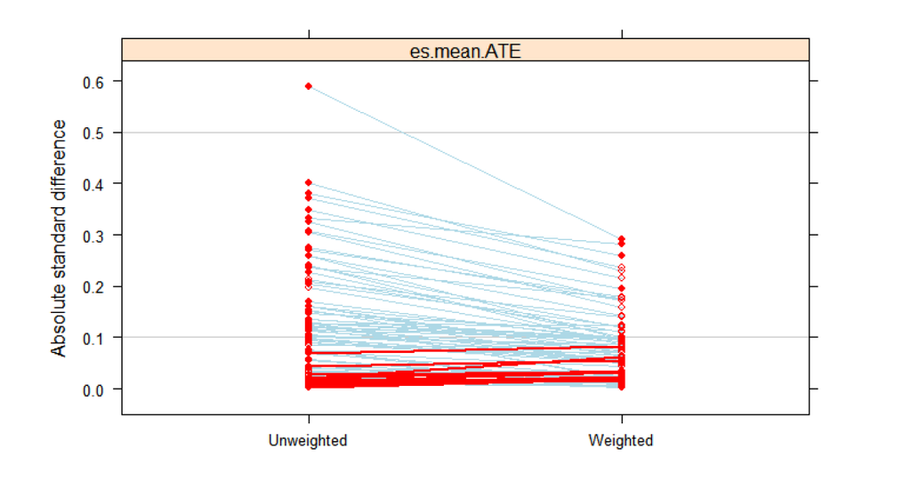

Figure 2: Effect size plot for the first GBM propensity score model

In order to achieve a more efficient propensity score model, we used the Akaike information criterion(AIC) to do the model selection with the output variable *G3*. Then the covariates that selected from the smallest AIC model were utilized to do the new propensity score model. Our new propensity score model includes the following covariates: *sex*, *age*, *famsize*, *Medu*, *Mjob*, *studytime*, *failures*, *schoolsup*, *famsup*, *romantic*, *freetime*, *goout*, and *absences*. The average ASMD for our new propensity score model is 0.15 when unweighted, and 0.057 when weighted. The improvement in weighting is notable; also, as illustrated in Figure 3’s effect size plot, all of the red circles are below 0.2. While some covariates are more unbalanced than before, our covariates are much more balanced overall.

[figure not shown]

List of covariates

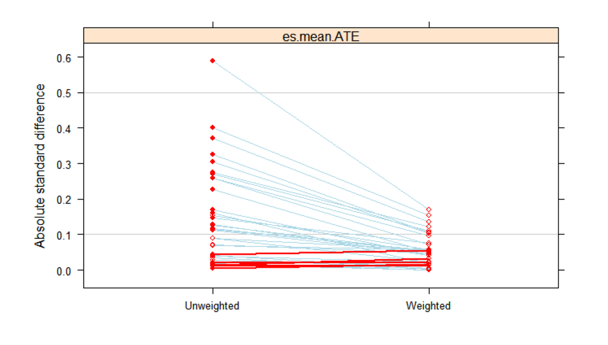

Figure 3: Effect size plot for the new GBM propensity score model

### 3.3 Estimation of average causal effects(ACE)

In this section, we use Propensity Score Matching and IPW to estimate average causal effects respectively.

#### 3.3.1 Propensity Score Matching

Due to the property of Propensity Score Matching, we first check overlapping status for the estimated propensity score. Figure 4 shows that the estimated propensity scores exist some overlapping issues. Also, the *student* dataset has almost 1:1 between the treatment group and control group. Therefore, we use **1:1 matching** with **replacement** to do the estimation in order to match treatment and control group by a reasonable propensity score.

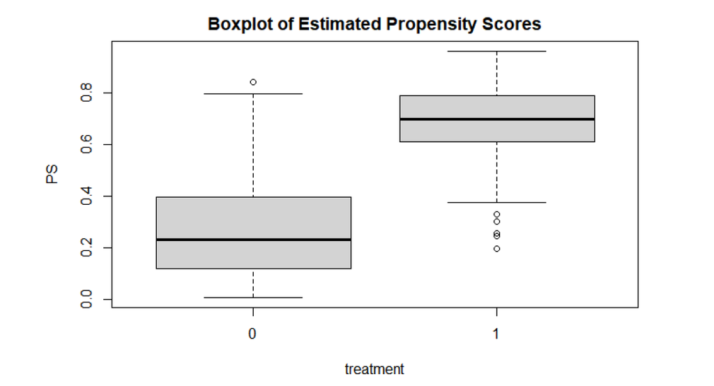

Figure 4: Boxplot for the estimated propensity scores

Results from matching using propensity estimation

|  | $ps_{GBM}$ | $ps_{Logistic}$ |
| --- | --- | --- |
| ACE | -0.12257 | 0.17426 |
| SE | 0.96565 | 0.54983 |
| t-value | -0.12693 | 0.31694 |
| p-value | 0.89899 | 0.75129 |

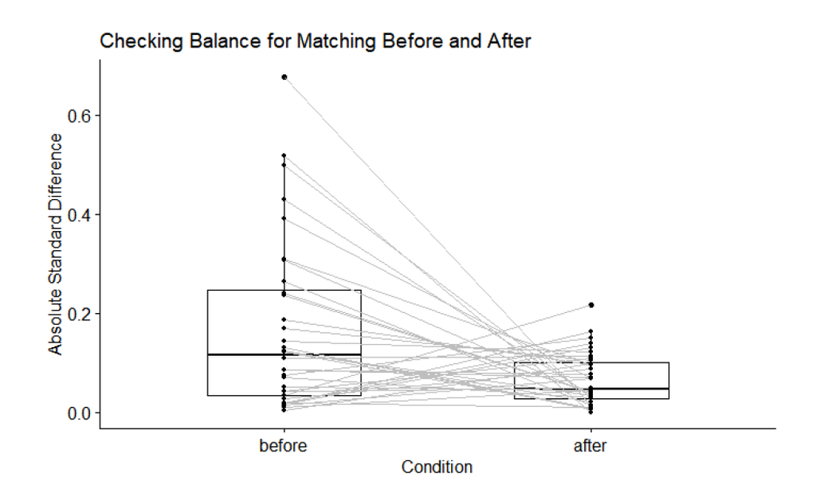

FIgure 5: Checking balance before and after matching using logistic propensity score model

However, in Figure 6, the AMSD value is based on matching using the GBM propensity score, which does not demonstrate adequate post-matching balance.

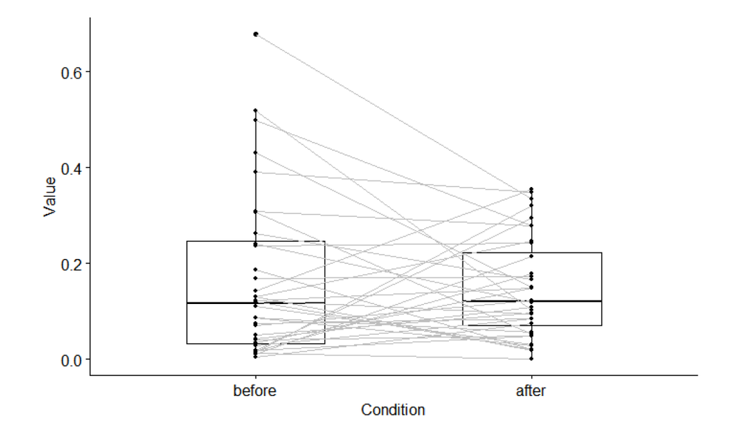

Figure 6: Checking balance before and after matching using GBM propensity score model

$ACE_{logistic}$ is more convincing compared to $ACE_{GBM}$ since the corresponding average ASMD decreases from 0.169 to 0.066 after matching. Thus, we conclude that joining in paid extra classes will result in 0.174 grades improvement, but the effect is not statistically significant because of high p-value.

#### 3.3.2 Inverse Probability Weighting

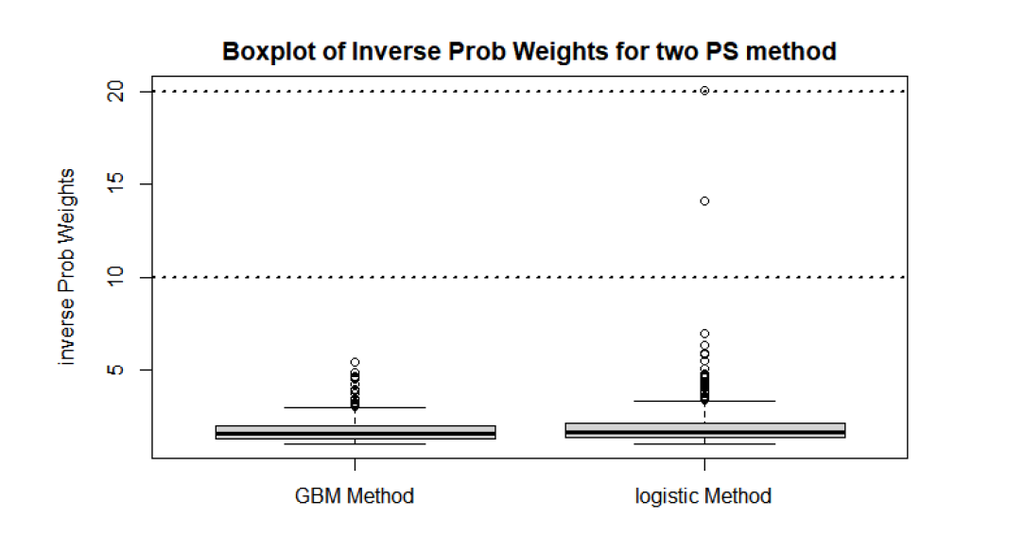

Figure 7: Boxplot of inverse probability weights for two PS method

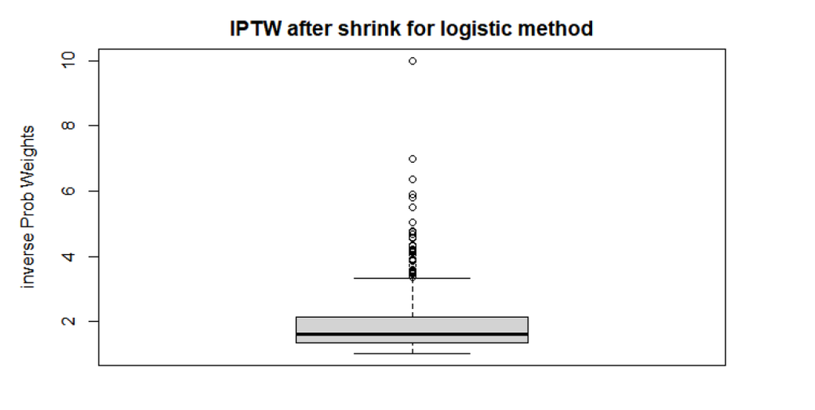

Figure 8: IPW using logistic propensity score model after shrinking

Table 2 presents ACEs under different weights. This time both of them perform similarly with positive values 0.452 and 0.379 respectively. The standard error across the different estimators is comparable around 0.5. Both p-value are still maintained at larger than 0.05, which illustrates that there is no significant evidence to declare the difference between paid-class takers and non-takers.

Results from IPW using propensity estimation

|  | $IPW_{GBM}$ | $IPW_{Logistic}$ |
| --- | --- | --- |
| ACE | 0.4518 | 0.3790 |
| SE | 0.4874 | 0.5053 |
| t-value | 0.927 | 0.75 |
| p-value | 0.355 | 0.454 |

#### 3.3.3 Comparison

The consistency and asymptotic normality of the above 4 estimators require the propensity score model to be correctly specified. However, misspecification in modeling is common in applications. Although the true propensity score model would not be feasible in applications, it can be regarded as approximately true if all the covariates are balanced after adjustment. In figure 9, the boxplots illustrate the comparison of ASMD for each covariates before and after these four methods. The boxplots indicate that Matching with *ps* and IPW with GBM have comparable balanced covariates after adjustment. But IPW with GBM is slightly better with smaller average ASMD, so our final ACE will based on the IPW with GBM

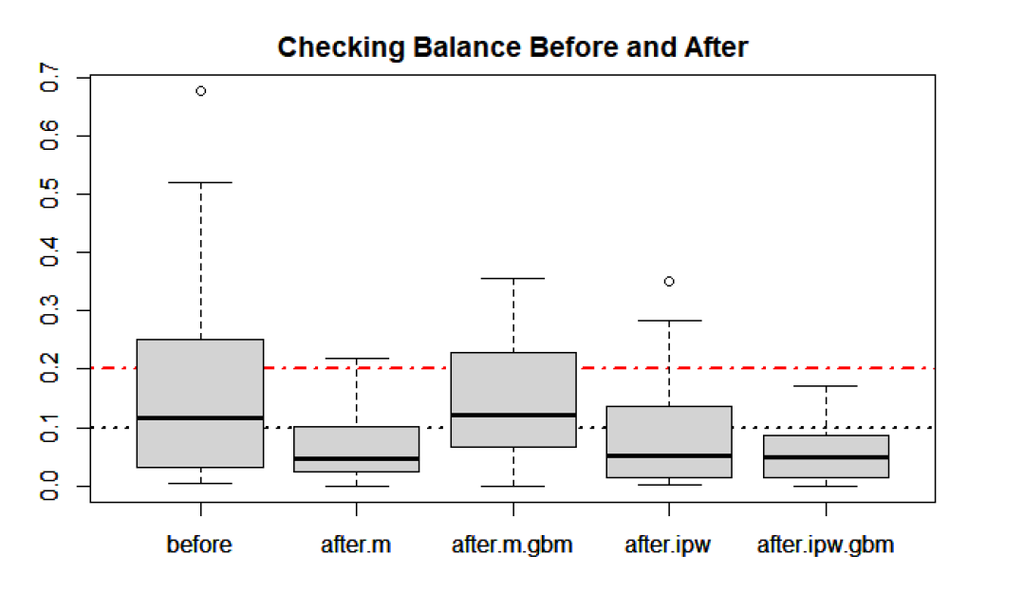

Figure 9: Checking balance before and after

## 4.Conclusion and Discussion

In this study, we investigate the causality between attending extra paid classes and good academic achievement of mathematics. The covariates including information in student grades, demographic, social and school related features are treated into confounders in the analysis.

The causality between taking extra paid classes and final grades are tested through propensity score based estimators. During the research, GBM and logistic regression models are implemented to calculate the propensity score, matching and IPW are used to find the interested causality.

In four methods proposed, the IPW with GBM method shows the best result in checking balance. The analysis estimate shows an increase in final grade of 0.4518 of those who take the extra paid classes compared with those who don’t. However, this effect is not statistically significant. Thus, there is no causality between taking extra paid classes and final grades in mathematics. This result coincides with the research conducted by Berberoğlu and Ömeroğulları (Berberoğlu & Tansel, 2014; Ömeroğulları et al., 2020). However, there exists social inequity between students who take extra paid classes and those who don’t. Students who take extra paid classes are more likely to be interested in mathematics and in a better economic situation. Thus, results may be biased by these factors.

Because of the data, the finding of this study is restricted to secondary school students in Portugal, the results might not be generalizable to all Portuguese students. In the future, students from more regions and school years should be involved in order to enrich the database.

Moreover, this research is on a propensity score based method on causal inference. These methods have limitations on controlling effects of unobserved or unmeasured confounding variables. Thus, there exists the probability that such confounding effects are still not excluded. In the future, extension of the propensity score is also required (Ha & Park, 2017).

## References

Berberoğlu, G., & Tansel, A. (2014). *Does private tutoring increase students’ academic performance? Evidence from Turkey. International Review of Education*. 60(5), 683–701. https://doi.org/10.1007/s11159-014-9436-y

Cortez, P., & Silva, A. (2008). *USING DATA MINING TO PREDICT SECONDARY SCHOOL STUDENT PERFORMANCE.* 8.

European Commission & Statistical Office of the European Union. (2007). Eurostat regional yearbook 2007.

Guill, K., & Bos, W. (2014). *Effectiveness of private tutoring in mathematics with regard to subjective and objective indicators of academic achievement. Evidence from a German secondary school sample. Journal for Educational Research Online.* 6(1), 34–67.

Ha, Y., & Park, H.-J. (2017). *Can after-school programs and private tutoring help improve students’ achievement? Revisiting the effects in Korean secondary schools. Asia Pacific Education Review.* 18(1), 65–79. https://doi.org/10.1007/s12564-016-9451-8

Matos, J. M. (2009). *Changing representations and practices in school mathematics: The case of Modern Math in Portugal.* 15.

Neto-Mendes, A., Costa, J. A., Ventura, A., Azevedo, S., & Gouveia, A. (2013). Private Tutoring in Portugal. In M. Bray, A. E. Mazawi, & R. G. Sultana (Eds.), *Private Tutoring Across the Mediterranean: Power Dynamics and Implications for Learning and Equity* (pp. 151–165). SensePublishers. https://doi.org/10.1007/978-94-6209-237-2_9

Ömeroğulları, M., Guill, K., & Köller, O. (2020). *Effectiveness of private tutoring during secondary schooling in Germany: Do the duration of private tutoring and tutor qualification affect school achievement? Learning and Instruction.* 66, 101306. https://doi.org/10.1016/j.learninstruc.2020.101306

The Ministry of Science, Technology and Higher Education. (2006). *OECD themaric review of theriary education—Country Background Report: PORTUGAL.*

*The role of mathematics in the overall curriculum | International Mathematical Union (IMU).* (2008). https://www.mathunion.org/icmi/role-mathematics-overall-curriculum

Zhang, Y. (2013). *Does private tutoring improve students’ National College Entrance Exam performance?—A case study from Jinan, China. Economics of Education Review.* 32, 1–28. https://doi.org/10.1016/j.econedurev.2012.09.008

Yeying, Zhu. (2021). Casusal Inference and Epidemiological Studies [PowerPoint slides]. Department of Statistics & Actuarial Science, University of Waterloo.

Berkson, J. (1944). *Application of the Logistic Function to Bio-Assay.* Journal of the American Statistical Association, 39(227), 357–365.

Rosenbaum, P. R., & Rubin, D. B. (1983). *The Central Role of the Propensity Score in Observational Studies for Causal Effects.* Biometrika, 70(1), 41–55.

Austin, P. C. (2009). *The Relative Ability of Different Propensity Score Methods to Balance Measured Covariates Between Treated and Untreated Subjects in Observational Studies.* Medical Decision Making, 29(6), 661–677.

Bernhard K. Flury & Hans Riedwyl (1986) *Standard Distance in Univariate and Multivariate Analysis.* The American Statistician, 40(3), 249-251

Friedman, J.H., T. Hastie, R. Tibshirani (2000). *Additive logistic regression: a statistical view of boosting.* Annals of Statistics, 28(2):337–374.

Lunceford JK, Davidian M. (2004). *Stratification and weighting via the propensity score in estimation of causal treatment effects: a comparative study.* Statist Med, 23(19):2937-2960.